# **Klasterisasi Provinsi Indonesia** Berdasarkan Indikator Kemiskinan Multidimensi

Hierarchical Clustering dengan Average Linkage | Data BPS 2022

Muhammad Rafli Azizan Universitas Diponegoro

17 May 2026

# 1 Pendahuluan

## 1.1 Latar Belakang

Kemiskinan merupakan salah satu permasalahan pembangunan yang paling kompleks di Indonesia. Sebagai negara kepulauan dengan 34 provinsi yang tersebar dari Sabang sampai Merauke, kondisi kemiskinan antarprovinsi menunjukkan kesenjangan yang sangat besar. Pada Maret 2022, tingkat kemiskinan nasional tercatat sebesar **9,54%**, namun angka ini menutupi disparitas yang tajam: Papua mencatat angka kemiskinan **26,56%** sementara Kepulauan Bangka Belitung hanya **4,47%**.

Pendekatan kebijakan yang seragam (*one-size-fits-all*) tidak efektif menghadapi heterogenitas kondisi antarprovinsi tersebut. Oleh karena itu, diperlukan **pengelompokan provinsi** berdasarkan kemiripan profil indikator kemiskinan sebagai dasar perumusan kebijakan yang lebih tepat sasaran.

## 1.2 Tujuan Analisis

Analisis ini bertujuan untuk:

1. Mengelompokkan (*cluster*) 34 provinsi Indonesia berdasarkan indikator kemiskinan multidimensi menggunakan metode *Hierarchical Clustering*
2. Mengidentifikasi profil karakteristik setiap kelompok provinsi
3. Menyajikan visualisasi spasial hasil klasterisasi dalam bentuk peta tematik

## 1.3 Pertanyaan Penelitian

> *“Bagaimana pengelompokan provinsi-provinsi di Indonesia berdasarkan kemiripan kondisi kemiskinan multidimensi, dan apa karakteristik yang membedakan setiap kelompok?”*

# 2 Data dan Variabel

## 2.1 Sumber Data

Data yang digunakan dalam analisis ini bersumber dari publikasi resmi **Badan Pusat Statistik (BPS) Republik Indonesia**, khususnya:

- *Statistik Indonesia 2023* (data tahun referensi 2022)
- *Profil Kemiskinan di Indonesia, Maret 2022*
- *Indeks Pembangunan Manusia 2022*

Unit analisis adalah **34 provinsi Indonesia** dengan periode data **tahun 2022**.

## 2.2 Variabel Penelitian

Tabel 1. Variabel yang Digunakan dalam Analisis

| No | Variabel | Nama Lengkap | Satuan | Sumber | Arah Kemiskinan |
| --- | --- | --- | --- | --- | --- |
| 1 | pct_miskin | Persentase Penduduk Miskin | % | BPS 2022 | ↑ Lebih tinggi = lebih miskin |
| 2 | ipm | Indeks Pembangunan Manusia | Indeks (0–100) | BPS 2022 | ↑ Lebih tinggi = lebih baik |
| 3 | tpt | Tingkat Pengangguran Terbuka | % | BPS 2022 | ↑ Lebih tinggi = lebih buruk |
| 4 | rls | Rata-rata Lama Sekolah | Tahun | BPS 2022 | ↑ Lebih tinggi = lebih baik |
| 5 | ahh | Angka Harapan Hidup | Tahun | BPS 2022 | ↑ Lebih tinggi = lebih baik |
| 6 | pdrb | PDRB per Kapita | Juta Rupiah | BPS 2022 | ↑ Lebih tinggi = lebih baik |

## 2.3 Statistik Deskriptif

Tabel 2. Statistik Deskriptif Variabel (34 Provinsi, 2022)

| Variabel | Min | Maks | Rerata | Median | SD |
| --- | --- | --- | --- | --- | --- |
| Angka Harapan Hidup (th) | 57.74 | 74.70 | 69.57 | 70.30 | 3.43 |
| IPM | 60.62 | 81.65 | 72.03 | 71.92 | 4.00 |
| % Penduduk Miskin (%) | 4.47 | 26.56 | 10.30 | 8.54 | 5.31 |
| PDRB per Kapita (juta Rp) | 14.99 | 281.26 | 57.13 | 42.85 | 54.46 |
| Rata-rata Lama Sekolah (th) | 6.66 | 11.06 | 8.69 | 8.70 | 0.98 |
| Tingkat Pengangguran (%) | 1.64 | 8.31 | 4.71 | 4.42 | 1.59 |

Tabel di atas menunjukkan variasi yang cukup besar pada hampir semua variabel, terutama pada **PDRB per Kapita** (SD = 54.5 juta rupiah) yang mengindikasikan ketimpangan ekonomi antarprovinsi yang sangat tinggi.

# 3 Metodologi

## 3.1 Hierarchical Clustering

Analisis ini menggunakan metode *Hierarchical Clustering* dengan konfigurasi:

| Parameter | Pilihan | Alasan |
| --- | --- | --- |
| Metode Linkage | Average (UPGMA) | Robust terhadap outlier; tepat untuk data provinsi yang heterogen |
| Ukuran Jarak | Euclidean | Standar untuk data numerik kontinu yang telah terstandarisasi |
| Standardisasi | Z-score | Menyeragamkan skala variabel yang berbeda satuan |

*Hierarchical Clustering* dipilih karena tidak memerlukan penentuan jumlah klaster di awal, menghasilkan dendrogram yang mudah diinterpretasikan, dan cocok untuk ukuran sampel kecil (n = 34).

## 3.2 Penentuan Jumlah Klaster

Jumlah klaster optimal ditentukan menggunakan dua metode:

1. **Silhouette Method** — memaksimalkan *average silhouette width* (SC)
2. **Elbow Method** — meminimalkan *within-cluster sum of squares* (WSS)

## 3.3 Uji Asumsi

Sebelum clustering, dua uji asumsi dilakukan:

- **Kaiser-Meyer-Olkin (KMO)** — mengukur kecukupan representasi sampel. Nilai ≥ 0.5 dipersyaratkan.
- **Matriks Korelasi** — mendeteksi multikolinearitas antar variabel (korelasi ≥ 0.8 menjadi perhatian).

# 4 Uji Asumsi

## 4.1 Uji KMO

Hasil uji KMO menghasilkan nilai **KMO Overall = 0.724**, yang masuk dalam kategori **“Baik” (*Middling*)** (0.70 ≤ KMO < 0.80). Nilai ini melebihi ambang batas minimum (≥ 0.50), sehingga **asumsi kecukupan sampel terpenuhi** dan analisis dapat dilanjutkan.

**✓ KMO = 0.724 — Asumsi representasi sampel TERPENUHI**

## 4.2 Analisis Korelasi Antarvariabel

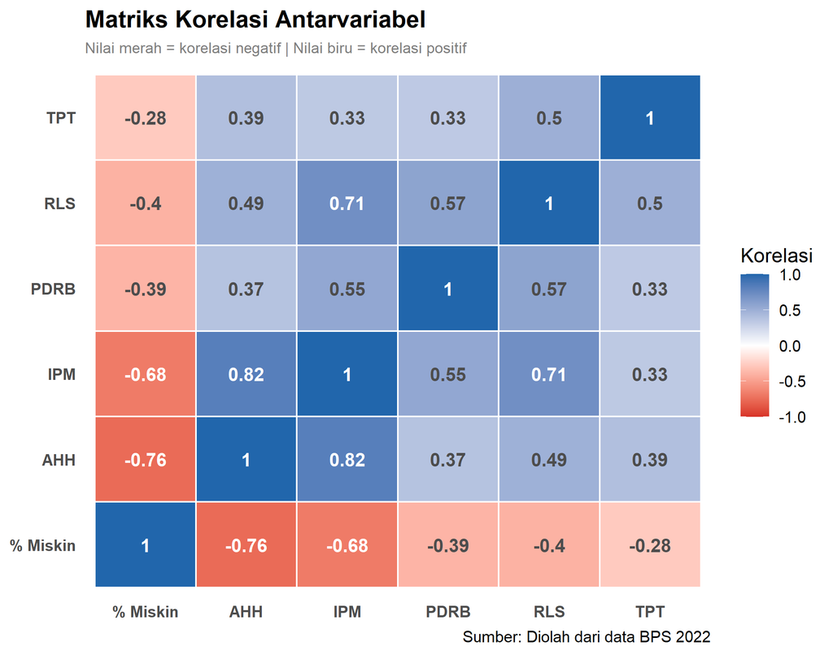

Gambar 1. Heatmap Matriks Korelasi Antarvariabel

Terdapat korelasi tinggi antara **IPM dan AHH** (r = 0.825), yang secara konstruksi memang berkaitan karena Angka Harapan Hidup merupakan salah satu komponen pembentuk IPM. Meskipun demikian, kedua variabel tetap dipertahankan dalam analisis ini karena keduanya mengukur dimensi yang berbeda: IPM mengukur pembangunan manusia secara agregat, sedangkan AHH mengukur dimensi kesehatan secara spesifik.

# 5 Hasil Clustering

## 5.1 Dendrogram

[figure not shown]

Gambar 2. Dendrogram Hierarchical Clustering 34 Provinsi Indonesia

Dendrogram menunjukkan struktur hierarki jarak antarprovinsi. Kotak berwarna menandai pembagian ke dalam **3 klaster** yang dipilih sebagai solusi final. Papua terlihat jelas sebagai *outlier* yang berdiri sendiri dengan jarak yang sangat jauh dari provinsi lainnya.

## 5.2 Penentuan Jumlah Klaster Optimal

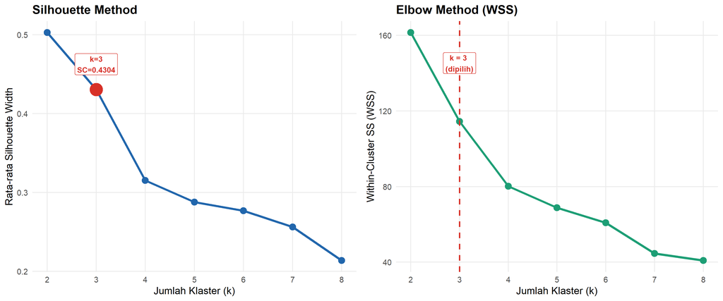

Gambar 3. Silhouette Method (kiri) dan Elbow Method (kanan) untuk Penentuan k Optimal

Tabel 3. Nilai Silhouette dan WSS untuk k = 2 sampai 8

| K | Silhouette (SC) | WSS | Interpretasi SC |
| --- | --- | --- | --- |
| 2 | 0.5027 | 161.47 | Cukup baik |
| 3 ← dipilih | 0.4304 | 114.49 | Lemah |
| 4 | 0.3152 | 80.12 | Lemah |
| 5 | 0.2879 | 68.82 | Lemah |
| 6 | 0.2768 | 60.86 | Lemah |
| 7 | 0.2562 | 44.63 | Lemah |
| 8 | 0.2138 | 40.90 | Tidak ada struktur |

**Justifikasi pemilihan k = 3:**

Secara statistik, nilai *Silhouette Coefficient* tertinggi dicapai pada **k = 2** (SC = 0.503). Namun solusi k = 2 menghasilkan klaster yang trivial: satu klaster berisi 33 provinsi dan satu klaster hanya berisi **Papua**. Pengelompokan ini kurang bermakna untuk kepentingan kebijakan.

## 5.3 Silhouette Individual

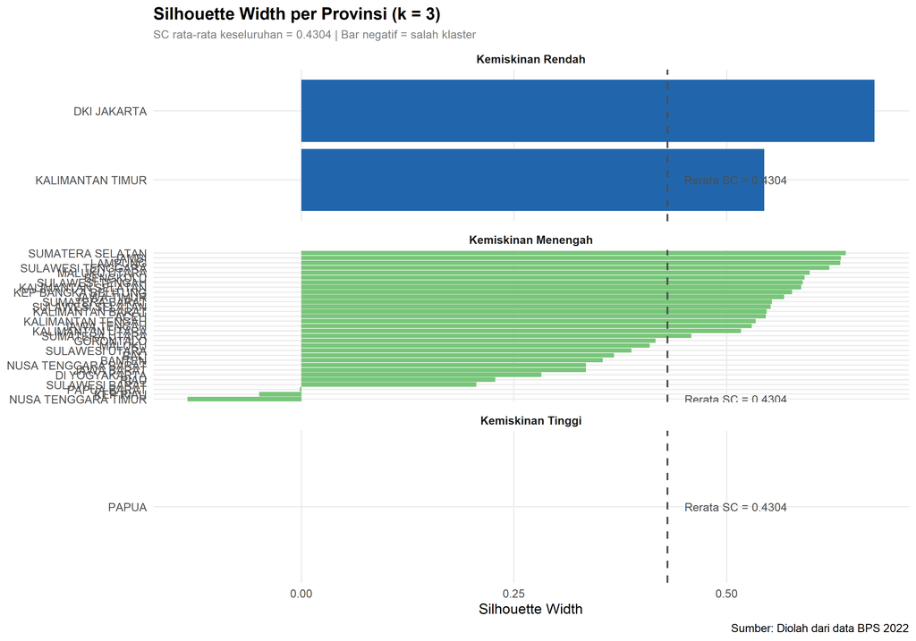

Gambar 4. Silhouette Width per Provinsi (k=3)

# 6 Profilisasi Klaster

## 6.1 Profil Statistik

Tabel 4. Profil Rata-rata Setiap Klaster (k=3)

| Klaster | Label | Jumlah Provinsi | % Miskin | IPM | TPT (%) | RLS (th) | AHH (th) | PDRB (juta Rp) |
| --- | --- | --- | --- | --- | --- | --- | --- | --- |
| 2 | Kemiskinan Rendah | 2 | 5.44 | 79.54 | 6.75 | 10.58 | 73.22 | 247.8 |
| 1 | Kemiskinan Menengah | 31 | 10.08 | 71.92 | 4.64 | 8.63 | 69.71 | 45.3 |
| 3 | Kemiskinan Tinggi | 1 | 26.56 | 60.62 | 2.67 | 6.66 | 57.74 | 43.3 |

## 6.2 Grafik Profil Klaster

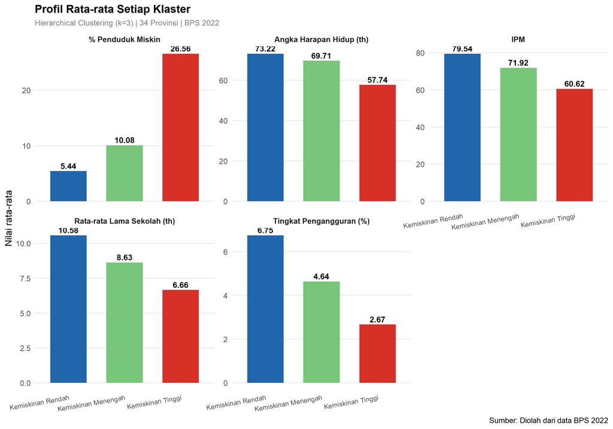

Gambar 5. Perbandingan Profil Rata-rata Setiap Klaster

## 6.3 Deskripsi Setiap Klaster

### Klaster Kemiskinan Rendah

**Provinsi:** DKI JAKARTA, KALIMANTAN TIMUR  
**Jumlah:** 2 provinsi

Klaster ini dicirikan oleh rata-rata persentase kemiskinan paling rendah (**5.44%**) dan IPM tertinggi (**79.54**). PDRB per kapita yang sangat tinggi (**247.8 juta rupiah**) mengindikasikan aktivitas ekonomi yang kuat, didorong oleh sektor pertambangan dan industri.

### Klaster Kemiskinan Menengah

**Provinsi:** ACEH, BALI, BANTEN, BENGKULU, DI YOGYAKARTA, GORONTALO, JAMBI, JAWA BARAT, JAWA TENGAH, JAWA TIMUR, KALIMANTAN BARAT, KALIMANTAN SELATAN, KALIMANTAN TENGAH, KALIMANTAN UTARA, KEP BANGKA BELITUNG, KEP RIAU, LAMPUNG, MALUKU, MALUKU UTARA, NUSA TENGGARA BARAT, NUSA TENGGARA TIMUR, PAPUA BARAT, RIAU, SULAWESI BARAT, SULAWESI SELATAN, SULAWESI TENGAH, SULAWESI TENGGARA, SULAWESI UTARA, SUMATERA BARAT, SUMATERA SELATAN, SUMATERA UTARA  
**Jumlah:** 31 provinsi

Klaster terbesar yang menampung mayoritas provinsi Indonesia. Tingkat kemiskinan berada di kisaran rata-rata nasional (**10.08%**) dengan kondisi IPM dan AHH yang moderat. Klaster ini sangat heterogen secara internal dan mencakup provinsi di Jawa, Sumatera, Kalimantan, Sulawesi, dan Nusa Tenggara.

### Klaster Kemiskinan Tinggi

**Provinsi:** PAPUA  
**Jumlah:** 1 provinsi

Klaster dengan tantangan kemiskinan paling berat. Tingkat kemiskinan mencapai **26.56%** — hampir tiga kali lipat rata-rata nasional. IPM sangat rendah (**60.62**) dan AHH hanya **57.74 tahun**, mengindikasikan keterbatasan akses layanan kesehatan dan pendidikan yang serius.

# 7 Visualisasi Spasial

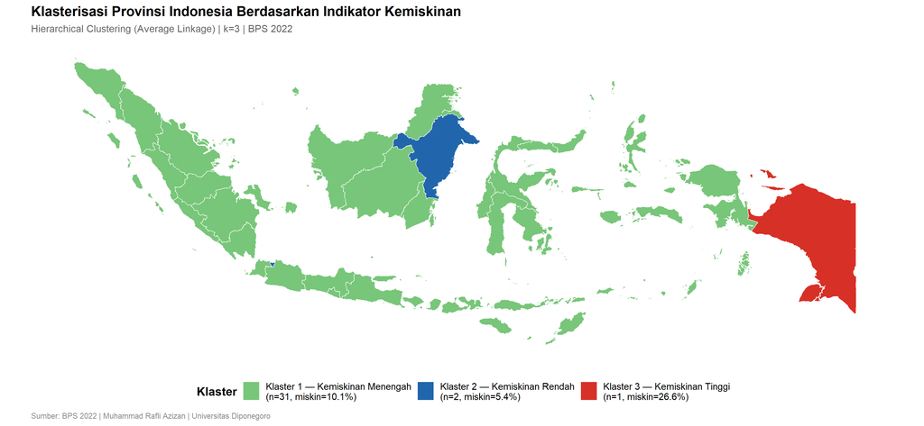

Gambar 6. Peta Klasterisasi Kemiskinan Provinsi Indonesia (BPS 2022)

Peta di atas memvisualisasikan hasil klasterisasi secara spasial. Terlihat bahwa provinsi-provinsi di **kawasan timur Indonesia** (Papua) membentuk klaster kemiskinan tinggi, sementara **DKI Jakarta dan Kalimantan Timur** menonjol sebagai klaster kemiskinan rendah yang dikelilingi oleh klaster menengah.

# 8 Pembahasan

## 8.1 Implikasi Kebijakan

Hasil klasterisasi ini memiliki implikasi kebijakan yang penting:

**Klaster Kemiskinan Tinggi (Papua)**

Membutuhkan intervensi kebijakan paling intensif, terutama: - Peningkatan aksesibilitas dan infrastruktur dasar (jalan, listrik, air bersih) - Penguatan layanan kesehatan primer untuk meningkatkan AHH - Perluasan program beasiswa dan sekolah jarak jauh untuk meningkatkan RLS - Program afirmasi khusus Papua yang sudah ada perlu evaluasi dan penguatan

**Klaster Kemiskinan Menengah (31 Provinsi)**

Menjadi prioritas utama dalam skala nasional karena menampung populasi terbesar. Kebijakan yang relevan: - Pengembangan ekonomi lokal berbasis komoditas unggulan daerah - Peningkatan konektivitas antarwilayah untuk mengurangi disparitas intra-klaster - Program vokasi dan peningkatan kualitas tenaga kerja

**Klaster Kemiskinan Rendah (DKI Jakarta & Kalimantan Timur)**

Dapat berperan sebagai *growth center* bagi wilayah sekitarnya melalui: - Penguatan konektivitas ekonomi dengan provinsi tetangga - Transfer pengetahuan dan teknologi - Pengembangan industri hilir dari sektor unggulan

## 8.2 Keterbatasan Analisis

1. Data menggunakan tahun referensi 2022 — kondisi terkini mungkin telah berubah, terutama pasca-pemekaran Papua
2. Analisis tidak mempertimbangkan dimensi kemiskinan non-monetaer seperti kerentanan dan ketidakberdayaan
3. Korelasi tinggi antara IPM dan AHH (r = 0.825) berpotensi memberikan bobot berlebih pada dimensi tersebut
4. Metode *Average Linkage* sensitif terhadap jumlah observasi yang kecil (n = 34)

# 9 Kesimpulan

Analisis klasterisasi menggunakan *Hierarchical Clustering* dengan *Average Linkage* terhadap 34 provinsi Indonesia berhasil mengidentifikasi **3 kelompok provinsi** yang berbeda secara karakteristik:

| Klaster | Jumlah Provinsi | % Miskin Rata-rata | Karakteristik Utama |
| --- | --- | --- | --- |
| Kemiskinan Rendah | 2 | 5.44% | PDRB dan IPM tinggi, sektor ekonomi dominan |
| Kemiskinan Menengah | 31 | 10.1% | Kondisi heterogen, mayoritas provinsi Indonesia |
| Kemiskinan Tinggi | 1 | 26.56% | Tantangan multidimensi yang serius |

# 10 Referensi

- Badan Pusat Statistik. (2023). *Statistik Indonesia 2023*. BPS RI.
- Badan Pusat Statistik. (2022). *Profil Kemiskinan di Indonesia, Maret 2022*. BPS RI.
- Badan Pusat Statistik. (2022). *Indeks Pembangunan Manusia 2022*. BPS RI.
- Kaufman, L., & Rousseeuw, P. J. (1990). *Finding Groups in Data: An Introduction to Cluster Analysis*. Wiley.
- Rousseeuw, P. J. (1987). Silhouettes: A graphical aid to the interpretation and validation of cluster analysis. *Journal of Computational and Applied Mathematics*, 20, 53–65.
- Ward, J. H. (1963). Hierarchical grouping to optimize an objective function. *Journal of the American Statistical Association*, 58(301), 236–244.

*Dokumen ini dibuat secara reproducible menggunakan R Markdown.*  
*Seluruh kode tersedia di repositori GitHub proyek ini.*  
*Digenerate pada: 17 May 2026, 21:22 WIB*